# Assessment 2

Avinash Meka (s4648886)

06/06/2021

£￡*Avinash Meka* **s4648886**

##Assignment 1

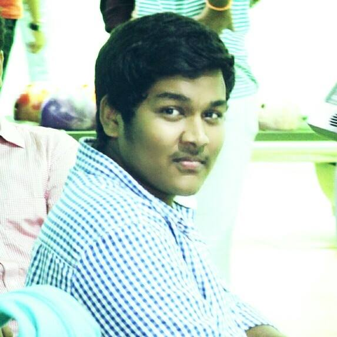

```r
library(tidyverse)
library(skimr)
library(scales)
theme_set(theme_light())
```

```r
thanksgiving_meals<-read_csv("https://raw.githubusercontent.com/rfordatascience/tidytuesday/master/data/2018/2018-11-20/thanksgiving_meals.csv")
```

#1 #Display the first 10 numbers

```r
thanksgiving_meals%>%head(10)
```

```
## # A tibble: 10 x 65
##        id celebrate main_dish main_dish_other main_prep main_prep_other stuffing
##     <dbl> <chr>     <chr>     <chr>           <chr>     <chr>           <chr>
##  1 4.34e9 Yes       Turkey    <NA>            Baked     <NA>            Bread-b…
##  2 4.34e9 Yes       Turkey    <NA>            Baked     <NA>            Bread-b…
##  3 4.34e9 Yes       Turkey    <NA>            Roasted   <NA>            Rice-ba…
##  4 4.34e9 Yes       Turkey    <NA>            Baked     <NA>            Bread-b…
##  5 4.34e9 Yes       Tofurkey  <NA>            Baked     <NA>            Bread-b…
##  6 4.34e9 Yes       Turkey    <NA>            Roasted   <NA>            Rice-ba…
##  7 4.34e9 Yes       Turkey    <NA>            Baked     <NA>            Bread-b…
##  8 4.34e9 Yes       Turkey    <NA>            Baked     <NA>            Rice-ba…
##  9 4.34e9 Yes       Turkey    <NA>            Roasted   <NA>            Bread-b…
## 10 4.34e9 Yes       Other (p… Turkey and Ham  Baked     <NA>            Bread-b…
## # … with 58 more variables: stuffing_other <chr>, cranberry <chr>,
## #   cranberry_other <chr>, gravy <chr>, side1 <chr>, side2 <chr>, side3 <chr>,
## #   side4 <chr>, side5 <chr>, side6 <chr>, side7 <chr>, side8 <chr>,
## #   side9 <chr>, side10 <chr>, side11 <chr>, side12 <chr>, side13 <chr>,
## #   side14 <chr>, side15 <chr>, pie1 <chr>, pie2 <chr>, pie3 <chr>, pie4 <chr>,
## #   pie5 <chr>, pie6 <chr>, pie7 <chr>, pie8 <chr>, pie9 <chr>, pie10 <chr>,
## #   pie11 <chr>, pie12 <chr>, pie13 <chr>, dessert1 <chr>, dessert2 <chr>,
## #   dessert3 <chr>, dessert4 <chr>, dessert5 <chr>, dessert6 <chr>,
## #   dessert7 <chr>, dessert8 <chr>, dessert9 <chr>, dessert10 <chr>,
## #   dessert11 <chr>, dessert12 <chr>, prayer <chr>, travel <chr>,
## #   watch_program <chr>, kids_table_age <chr>, hometown_friends <chr>,
## #   friendsgiving <chr>, black_friday <chr>, work_retail <chr>,
## #   work_black_friday <chr>, community_type <chr>, age <chr>, gender <chr>,
## #   family_income <chr>, us_region <chr>
```

#1 ans- Displaying the first observations from the dataset using head(10) function.

#2 #Use fct_reorder and parse number to factor variable family_income.

```r
thanksgiving_meals%>%
  mutate(family_income = fct_reorder(family_income, parse_number(family_income)))
```

```
## # A tibble: 1,058 x 65
##        id celebrate main_dish main_dish_other main_prep main_prep_other stuffing
##     <dbl> <chr>     <chr>     <chr>           <chr>     <chr>           <chr>
##  1 4.34e9 Yes       Turkey    <NA>            Baked     <NA>            Bread-b…
##  2 4.34e9 Yes       Turkey    <NA>            Baked     <NA>            Bread-b…
##  3 4.34e9 Yes       Turkey    <NA>            Roasted   <NA>            Rice-ba…
##  4 4.34e9 Yes       Turkey    <NA>            Baked     <NA>            Bread-b…
##  5 4.34e9 Yes       Tofurkey  <NA>            Baked     <NA>            Bread-b…
##  6 4.34e9 Yes       Turkey    <NA>            Roasted   <NA>            Rice-ba…
##  7 4.34e9 Yes       Turkey    <NA>            Baked     <NA>            Bread-b…
##  8 4.34e9 Yes       Turkey    <NA>            Baked     <NA>            Rice-ba…
##  9 4.34e9 Yes       Turkey    <NA>            Roasted   <NA>            Bread-b…
## 10 4.34e9 Yes       Other (p… Turkey and Ham  Baked     <NA>            Bread-b…
## # … with 1,048 more rows, and 58 more variables: stuffing_other <chr>,
## #   cranberry <chr>, cranberry_other <chr>, gravy <chr>, side1 <chr>,
## #   side2 <chr>, side3 <chr>, side4 <chr>, side5 <chr>, side6 <chr>,
## #   side7 <chr>, side8 <chr>, side9 <chr>, side10 <chr>, side11 <chr>,
## #   side12 <chr>, side13 <chr>, side14 <chr>, side15 <chr>, pie1 <chr>,
## #   pie2 <chr>, pie3 <chr>, pie4 <chr>, pie5 <chr>, pie6 <chr>, pie7 <chr>,
## #   pie8 <chr>, pie9 <chr>, pie10 <chr>, pie11 <chr>, pie12 <chr>, pie13 <chr>,
## #   dessert1 <chr>, dessert2 <chr>, dessert3 <chr>, dessert4 <chr>,
## #   dessert5 <chr>, dessert6 <chr>, dessert7 <chr>, dessert8 <chr>,
## #   dessert9 <chr>, dessert10 <chr>, dessert11 <chr>, dessert12 <chr>,
## #   prayer <chr>, travel <chr>, watch_program <chr>, kids_table_age <chr>,
## #   hometown_friends <chr>, friendsgiving <chr>, black_friday <chr>,
## #   work_retail <chr>, work_black_friday <chr>, community_type <chr>,
## #   age <chr>, gender <chr>, family_income <fct>, us_region <chr>
```

#2 ans- fct_reorder is used to reorder a factor where it is mapped to a position.Parse_number function is a non-numeric characters before or after the group. Here family_income is used to reorder and parsed to make a factor.

#3 #Generate the statistics using summary and skim functions to display the types of the variables in a dataset.

```r
thanksgiving_meals%>%summary()
```

```
##        id             celebrate          main_dish         main_dish_other
##  Min.   :4.336e+09   Length:1058        Length:1058        Length:1058
##  1st Qu.:4.336e+09   Class :character   Class :character   Class :character
##  Median :4.337e+09   Mode  :character   Mode  :character   Mode  :character
##  Mean   :4.337e+09
##  3rd Qu.:4.337e+09
##  Max.   :4.338e+09
##   main_prep         main_prep_other      stuffing         stuffing_other
##  Length:1058        Length:1058        Length:1058        Length:1058
##  Class :character   Class :character   Class :character   Class :character
##  Mode  :character   Mode  :character   Mode  :character   Mode  :character
##
##
##
##   cranberry         cranberry_other       gravy              side1
##  Length:1058        Length:1058        Length:1058        Length:1058
##  Class :character   Class :character   Class :character   Class :character
##  Mode  :character   Mode  :character   Mode  :character   Mode  :character
##
##
##
##     side2              side3              side4              side5
##  Length:1058        Length:1058        Length:1058        Length:1058
##  Class :character   Class :character   Class :character   Class :character
##  Mode  :character   Mode  :character   Mode  :character   Mode  :character
##
##
##
##     side6              side7              side8              side9
##  Length:1058        Length:1058        Length:1058        Length:1058
##  Class :character   Class :character   Class :character   Class :character
##  Mode  :character   Mode  :character   Mode  :character   Mode  :character
##
##
##
##     side10             side11             side12             side13
##  Length:1058        Length:1058        Length:1058        Length:1058
##  Class :character   Class :character   Class :character   Class :character
##  Mode  :character   Mode  :character   Mode  :character   Mode  :character
##
```

[output cut: 64 more lines]

```
##
##  community_type         age               gender          family_income
##  Length:1058        Length:1058        Length:1058        Length:1058
##  Class :character   Class :character   Class :character   Class :character
##  Mode  :character   Mode  :character   Mode  :character   Mode  :character
##
##
##
##   us_region
##  Length:1058
##  Class :character
##  Mode  :character
##
##
##
```

```r
thanksgiving_meals%>%skim()
```

Data summary

| Name | Piped data |
| --- | --- |
| Number of rows | 1058 |
| Number of columns | 65 |
| _______________________ |  |
| Column type frequency: |  |
| character | 64 |
| numeric | 1 |
| ________________________ |  |
| Group variables | None |

**Variable type: character**

| skim_variable | n_missing | complete_rate | min | max | empty | n_unique | whitespace |
| --- | --- | --- | --- | --- | --- | --- | --- |
| celebrate | 0 | 1.00 | 2 | 3 | 0 | 2 | 0 |
| main_dish | 84 | 0.92 | 6 | 22 | 0 | 8 | 0 |
| main_dish_other | 1023 | 0.03 | 4 | 85 | 0 | 32 | 0 |
| main_prep | 84 | 0.92 | 5 | 22 | 0 | 5 | 0 |
| main_prep_other | 1007 | 0.05 | 1 | 33 | 0 | 32 | 0 |
| stuffing | 84 | 0.92 | 4 | 22 | 0 | 4 | 0 |
| stuffing_other | 1022 | 0.03 | 4 | 46 | 0 | 29 | 0 |
| cranberry | 84 | 0.92 | 4 | 22 | 0 | 4 | 0 |
| cranberry_other | 1033 | 0.02 | 3 | 61 | 0 | 24 | 0 |
| gravy | 84 | 0.92 | 2 | 3 | 0 | 2 | 0 |
| side1 | 903 | 0.15 | 15 | 15 | 0 | 1 | 0 |
| side2 | 816 | 0.23 | 7 | 7 | 0 | 1 | 0 |
| side3 | 970 | 0.08 | 11 | 11 | 0 | 1 | 0 |
| side4 | 594 | 0.44 | 4 | 4 | 0 | 1 | 0 |
| side5 | 823 | 0.22 | 9 | 9 | 0 | 1 | 0 |
| side6 | 843 | 0.20 | 11 | 11 | 0 | 1 | 0 |
| side7 | 372 | 0.65 | 32 | 32 | 0 | 1 | 0 |
| side8 | 852 | 0.19 | 19 | 19 | 0 | 1 | 0 |
| side9 | 241 | 0.77 | 15 | 15 | 0 | 1 | 0 |
| side10 | 292 | 0.72 | 14 | 14 | 0 | 1 | 0 |
| side11 | 887 | 0.16 | 6 | 6 | 0 | 1 | 0 |
| side12 | 849 | 0.20 | 15 | 15 | 0 | 1 | 0 |
| side13 | 427 | 0.60 | 27 | 27 | 0 | 1 | 0 |
| side14 | 947 | 0.10 | 22 | 22 | 0 | 1 | 0 |
| side15 | 947 | 0.10 | 4 | 78 | 0 | 89 | 0 |
| pie1 | 544 | 0.49 | 5 | 5 | 0 | 1 | 0 |
| pie2 | 1023 | 0.03 | 10 | 10 | 0 | 1 | 0 |
| pie3 | 945 | 0.11 | 6 | 6 | 0 | 1 | 0 |
| pie4 | 925 | 0.13 | 9 | 9 | 0 | 1 | 0 |
| pie5 | 1022 | 0.03 | 13 | 13 | 0 | 1 | 0 |
| pie6 | 1019 | 0.04 | 8 | 8 | 0 | 1 | 0 |
| pie7 | 1024 | 0.03 | 5 | 5 | 0 | 1 | 0 |
| pie8 | 716 | 0.32 | 5 | 5 | 0 | 1 | 0 |
| pie9 | 329 | 0.69 | 7 | 7 | 0 | 1 | 0 |
| pie10 | 906 | 0.14 | 12 | 12 | 0 | 1 | 0 |
| pie11 | 1018 | 0.04 | 4 | 4 | 0 | 1 | 0 |
| pie12 | 987 | 0.07 | 22 | 22 | 0 | 1 | 0 |
| pie13 | 987 | 0.07 | 5 | 46 | 0 | 61 | 0 |
| dessert1 | 948 | 0.10 | 13 | 13 | 0 | 1 | 0 |
| dessert2 | 1042 | 0.02 | 8 | 8 | 0 | 1 | 0 |
| dessert3 | 930 | 0.12 | 8 | 8 | 0 | 1 | 0 |
| dessert4 | 986 | 0.07 | 11 | 11 | 0 | 1 | 0 |
| dessert5 | 867 | 0.18 | 10 | 10 | 0 | 1 | 0 |
| dessert6 | 854 | 0.19 | 7 | 7 | 0 | 1 | 0 |
| dessert7 | 1015 | 0.04 | 5 | 5 | 0 | 1 | 0 |
| dessert8 | 792 | 0.25 | 9 | 9 | 0 | 1 | 0 |
| dessert9 | 955 | 0.10 | 13 | 13 | 0 | 1 | 0 |
| dessert10 | 763 | 0.28 | 4 | 4 | 0 | 1 | 0 |
| dessert11 | 924 | 0.13 | 22 | 22 | 0 | 1 | 0 |
| dessert12 | 924 | 0.13 | 3 | 59 | 0 | 92 | 0 |
| prayer | 99 | 0.91 | 2 | 3 | 0 | 2 | 0 |
| travel | 107 | 0.90 | 59 | 80 | 0 | 4 | 0 |
| watch_program | 556 | 0.47 | 13 | 13 | 0 | 1 | 0 |
| kids_table_age | 107 | 0.90 | 2 | 13 | 0 | 12 | 0 |
| hometown_friends | 107 | 0.90 | 2 | 3 | 0 | 2 | 0 |
| friendsgiving | 107 | 0.90 | 2 | 3 | 0 | 2 | 0 |
| black_friday | 107 | 0.90 | 2 | 3 | 0 | 2 | 0 |
| work_retail | 107 | 0.90 | 2 | 3 | 0 | 2 | 0 |
| work_black_friday | 988 | 0.07 | 2 | 13 | 0 | 3 | 0 |
| community_type | 110 | 0.90 | 5 | 8 | 0 | 3 | 0 |
| age | 33 | 0.97 | 3 | 7 | 0 | 4 | 0 |
| gender | 33 | 0.97 | 4 | 6 | 0 | 2 | 0 |
| family_income | 33 | 0.97 | 12 | 20 | 0 | 11 | 0 |
| us_region | 59 | 0.94 | 7 | 18 | 0 | 9 | 0 |

**Variable type: numeric**

| skim_variable | n_missing | complete_rate | mean | sd | p0 | p25 | p50 | p75 | p100 | hist |
| --- | --- | --- | --- | --- | --- | --- | --- | --- | --- | --- |
| id | 0 | 1 | 4336731188 | 493783.4 | 4335894916 | 4336339486 | 4336796628 | 4337012140 | 4337954960 | ▅▃▇▂▂ |

#3 ans-Summary function is used to produce result summaires of various types in the dataset.Skim function can also be used as an alternative function to summary and additionally also displays all data types of the variables in the dataset thanksgiving_meals.

#4 #To count the people who celecrate thanksgiving.

```r
thanksgiving_meals%>%count(celebrate,sort = TRUE)
```

```
## # A tibble: 2 x 2
##   celebrate     n
##   <chr>     <int>
## 1 Yes         980
## 2 No           78
```

#4-ans Count function is used to calculate the unique values of the variables to show the total number of observations under the variables.

#5 #What are categories and stats for each main dish served and the method it is prepared?

```r
stats<-thanksgiving_meals%>%
  count(main_dish,main_prep,sort = TRUE)
```

#6 #Data viz to plot the maindish served and the method used to prepare it.

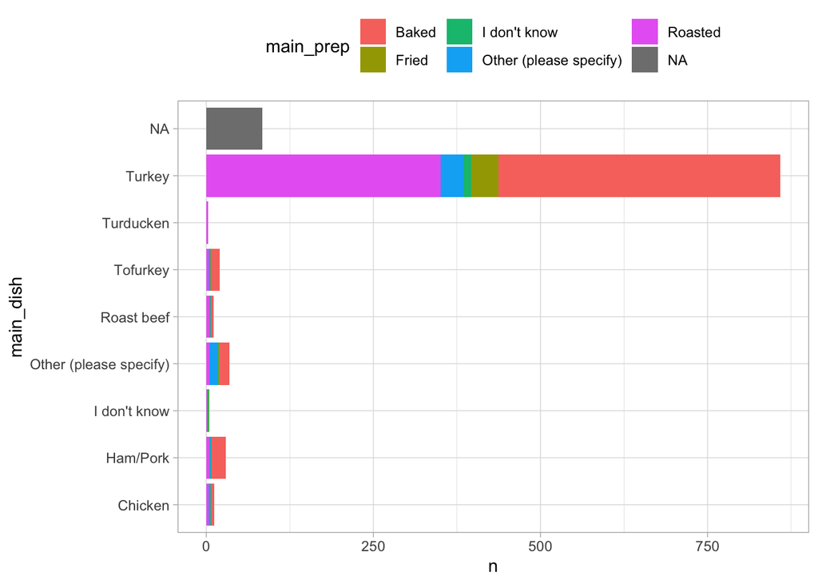

```r
stats%>%ggplot(aes(n,main_dish,fill=main_prep))+geom_col()+theme(legend.position = "top")
```

#6 answ–ggplot is a function used plot various graphs models for a specific values in a dataset.A plot is marked between maindish and maindish preparation.

#7 #Count the people who choose cranberry sauce and gravy.

```r
thanksgiving_meals%>%count(gravy,sort = TRUE)
```

```
## # A tibble: 3 x 2
##   gravy     n
##   <chr> <int>
## 1 Yes     892
## 2 <NA>     84
## 3 No       82
```

```r
thanksgiving_meals%>%count(cranberry,sort = TRUE)
```

```
## # A tibble: 5 x 2
##   cranberry                  n
##   <chr>                  <int>
## 1 Canned                   502
## 2 Homemade                 301
## 3 None                     146
## 4 <NA>                      84
## 5 Other (please specify)    25
```

#7 ans–To individually calculate the total number of people using gravy and cranberry.

#8 #Distribution of people who celebrate thanksgiving based on their income.

```r
family_celebrate<-thanksgiving_meals%>%
  group_by(family_income)%>%
  summarise(celebrate = sum(celebrate == "Yes"))%>%ungroup()
```

#8 ans–family_celebrate is a new dataset extracted from thanksgiving and grouping the people based on their family incomes and summarising them on celebration of thanksgiving.Finally ungrouping them.

#9 #Dataviz for people who celebrate thanksgiving based on their income.

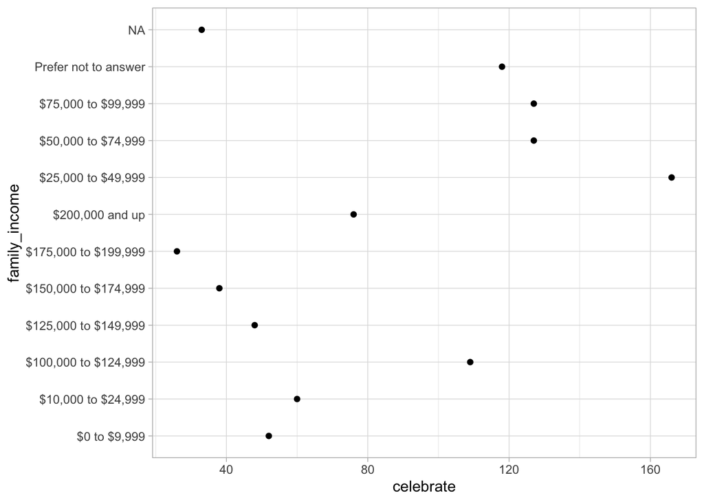

```r
family_celebrate%>%
  ggplot(aes(celebrate,family_income))+
  geom_point()
```

#9 ans- Plotting a geom_point with the criteria of celebration vs family_income.

#10 #The most commonly choosen sides, pies and deserts in a dataset.

```r
common<- thanksgiving_meals%>%
  select(id, starts_with("side"),
         starts_with("pie"),
         starts_with("dessert")) %>%
  select(-side15,-pie13,-dessert12)%>%
  gather(type, value,-id)%>%
  filter(!is.na(value),
         !value %in% c("None", "Other (please specify)"))%>%
  mutate(type = str_remove(type, "\\d+"))

common<-common%>%
  count(type,value,sort = TRUE)
```

#11 #Dataviz to provide the common sides, pies and deserts.

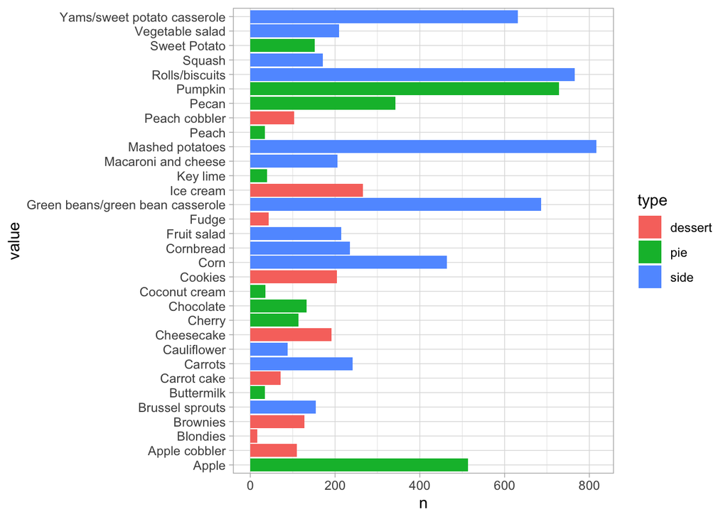

```r
common%>%
  ggplot(aes(n,value,fill = type))+
  geom_col()
```

#11 ans- Presenting geom_col for the common sides,pies and deserts.

#12 #How do the servings differ by income?

```r
servings<-thanksgiving_meals%>%
  select(id, starts_with("side"),
         starts_with("pie"),
         starts_with("dessert"),
         starts_with("main_dish")) %>%
  select(-side15,-pie13,-dessert12)%>%
  gather(type, food,-id)%>%
  filter(!is.na(food),
         !food %in% c("None", "Other (please specify)"))%>%
  mutate(type = str_remove(type, "\\d+"))

servings<-servings%>%
  inner_join(thanksgiving_meals)%>%
  mutate(income = parse_number(family_income))%>%
  group_by(food)%>%
  summarise(family_income)%>%
  arrange(family_income)
servings<-servings%>%count(food,family_income,sort = TRUE)
```

#12-ans-Created a new dataset which drawed from the main dataset thanksgiving_meals to store the observations of servings varied by income.Initially used the function innerjoin and mutating coloums matching rows based on the common sides, pies and desserts. Grouping them by food along with summarising by family_income, as which which food will be selected by the which family_income category and then arranged to the family_income. Counting the total observations from the dataset servings.

#13 # Present this information on a data viz

[figure not shown]

```r
servings%>%ggplot(aes(family_income,food))+geom_point()
```

#13-ans Marking a point between family_income and food choosed by the people using ggplot function.